# Travel insurance classification

The following project aims to build several ML classifiers which may help travel agencies to predict if their clients decide to buy an insurance during introductory offering. Project was divided into sections which covers exploratory data analysis, data preprocessing, training models and assessment of their prediction abilities.

As an outcome, four different classifiers were built: k-Nearest Neighbours, Naive Bayes Classifier, Logistic Regression and Classification Tree. Various performance measures were used to evaluate models' performances. Additionally, to handle issue with class-inbalanced data, models were assessed for two different thresholds. Another method used was SMOTE algorithm which is example of oversampling.

The results of the project shows that Classification Tree has the best classification abilities and outperforms other models. Additionally, all built classifiers are good in detecting people who are not keen to buy an insurance during introductory offering but are rather poor in detecting individuals who buy a insurance. Methods applied to boost the ability of positive classes classification have worked but resulted in drop of overall model accuracy and ability to detect negative classes. After comparison, the basic Classification Tree model was still better than other models. K-Nearest Neigbour was selected as an alternative, which can identify people who buy an insurance better than the Tree.

## 1. Exploratory data analysis

### 1.1 Importing modules

```python
import pandas as pd
import re
import matplotlib.pyplot as plt
import numpy as np
import seaborn as sns
import warnings

from statistics import mean
from sklearn.model_selection import train_test_split
from sklearn.neighbors import KNeighborsClassifier
# pip install mixed-naive-bayes
from mixed_naive_bayes import MixedNB
from sklearn.linear_model import LogisticRegression
from sklearn.tree import DecisionTreeClassifier, export_text, plot_tree
from sklearn.model_selection import StratifiedKFold
from imblearn.over_sampling import SMOTE
from sklearn.metrics import accuracy_score, f1_score, confusion_matrix, roc_auc_score, roc_curve, plot_confusion_matrix

pd.set_option('display.float_format', lambda x: '%.3f' % x)
warnings.filterwarnings('ignore')
seed = 123
```

```python
def load_plot_settings(palette=sns.diverging_palette(235, 120, n=11)):
    """Loads standard plot configuration."""
    sns.set_style("whitegrid")
    sns.set_palette(palette)
    sns.set_context("paper", rc={"font.size":14, "axes.titlesize":15, "axes.labelsize":14})

load_plot_settings()
```

### 1.2 Variables description

The analysed dataset consists of 1000 records and 9 columns. First 8 features describe customers of travel agency. The last column is target variable which states if the person bought the insurance or nor. Dataset doesn't have any missing values. Detailed column descriprions are as follows:

- **Age** - age of the customer,
- **Employment Type** - the sector in which customer is employed,
- **Graduate Or Not** - whether the customer is college graduate or not,
- **Annual Income** - the yearly income of the customer in indian rupees,
- **Family Members** - number of members in customer's family
- **Chronic Diseases** - whether the customer suffers from any major disease or conditions like diabetes, high bp, asthama, etc.,
- **Frequent Flyer** - derived data based on customer's history of booking air tickets on atleast 4 different instances in the last 2 years,
- **Ever Travelled Abroad** - has the customer ever travelled to a foreign country,
- **Travel Insurance** - did the customer buy travel insurance package during introductory offering held.

```python
raw_data = pd.read_csv("TravelInsurance.csv", sep=";")
raw_data.head()
```

|  | Age | Employment.Type | GraduateOrNot | AnnualIncome | FamilyMembers | ChronicDiseases | FrequentFlyer | EverTravelledAbroad | TravelInsurance |
| --- | --- | --- | --- | --- | --- | --- | --- | --- | --- |
| 0 | 26 | Private Sector/Self Employed | Yes | 1400000 | 4 | 0 | Yes | Yes | 1 |
| 1 | 26 | Private Sector/Self Employed | Yes | 450000 | 4 | 0 | No | No | 0 |
| 2 | 27 | Private Sector/Self Employed | No | 1550000 | 6 | 0 | Yes | No | 1 |
| 3 | 34 | Private Sector/Self Employed | Yes | 700000 | 6 | 0 | No | No | 1 |
| 4 | 29 | Private Sector/Self Employed | Yes | 1050000 | 7 | 0 | Yes | No | 1 |

```python
raw_data.shape
```

```
(1000, 9)
```

```python
raw_data.info()
```

```
<class 'pandas.core.frame.DataFrame'>
RangeIndex: 1000 entries, 0 to 999
Data columns (total 9 columns):
 #   Column               Non-Null Count  Dtype
---  ------               --------------  -----
 0   Age                  1000 non-null   int64
 1   Employment.Type      1000 non-null   object
 2   GraduateOrNot        1000 non-null   object
 3   AnnualIncome         1000 non-null   int64
 4   FamilyMembers        1000 non-null   int64
 5   ChronicDiseases      1000 non-null   int64
 6   FrequentFlyer        1000 non-null   object
 7   EverTravelledAbroad  1000 non-null   object
 8   TravelInsurance      1000 non-null   int64
dtypes: int64(5), object(4)
memory usage: 70.4+ KB
```

```python
# make column names consistent
old_cols = raw_data.columns
raw_data.columns = "age, empl_type, graduate, income, family, " \
                    "chronic_disease, freq_flyer, travel_abroad, " \
                    "insurance".split(", ")

# create another dataframe for plotting the data
plot_data = raw_data.copy()

# prettify column names to make them looks better on plots
def prettify_text(text):
    text = text.replace(".", "")
    text = " ".join(re.sub(r"([A-Z])", r" \1", text).split())
    text = text[0] + text[1:].lower()
    return text

binary_map = {0: "No", 1: "Yes"}
plot_data["insurance"] = plot_data["insurance"].map(binary_map)
plot_data["chronic_disease"] = plot_data["chronic_disease"].map(binary_map)
plot_data.columns = [prettify_text(col) for col in old_cols]
```

### 1.3. Data Visualization

#### Target variable - purchase of insurance

Out of 1000 customers, only 308 bought the insurance what indicates that in the dataset occurs class imbalance problem. Ratio of positive class is twice lower than ratio of negative class.

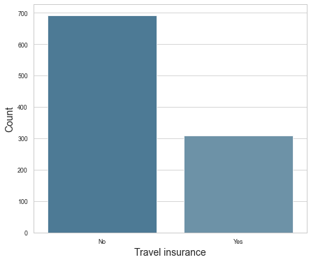

```python
plt.figure(figsize=(7,6))
ax = sns.countplot(data=plot_data,
                   x="Travel insurance",
                   order=plot_data["Travel insurance"].value_counts().index)
ax.set(ylabel="Count")
plt.show()
```

```python
plot_data["Travel insurance"].value_counts()
```

```
No     692
Yes    308
Name: Travel insurance, dtype: int64
```

#### **Quantitative variables**

##### **Descriptive statistics**

The table below shows the descriptive statistics of quantitative variables. The average agency customer was about 30 years old. Customers' age doesn't vary a lot. Analysed individuals were rather young, the minimum and maximum values for age are 25 and 35 years respectively. The average annual income was equal to about 916k indian rupees. The minimum salary was three times lower, while the biggest one - twice higher. Analyzed customers usually have about 5 family members. A person having the biggest family has 9 family members.

```python
quant_cols = ["Age", "Annual income", "Family members"]
ord_cols = ["Age", "Family members"]
plot_data[quant_cols].describe().T
```

|  | count | mean | std | min | 25% | 50% | 75% | max |
| --- | --- | --- | --- | --- | --- | --- | --- | --- |
| Age | 1000.000 | 29.590 | 2.886 | 25.000 | 28.000 | 29.000 | 32.000 | 35.000 |
| Annual income | 1000.000 | 916100.000 | 378661.028 | 300000.000 | 600000.000 | 900000.000 | 1200000.000 | 1800000.000 |
| Family members | 1000.000 | 4.731 | 1.593 | 2.000 | 4.000 | 5.000 | 6.000 | 9.000 |

##### **Annual income**

Both histogram and boxplots of annual income do not suggest presence of any significant outliers, although the distribution is not uniform across the values. It can be noticed that there are many individuals whose salaries are rather low. Additionally, histogram bars drop rapidly on the right tail indicating that there is a break between people of moderate means and people who earn more than 1,600,000 indian rupees per year. The plot may even suggest presence of social classes: upper, working and middle. In addition, even in the middle class it looks like there is division into lower and upper class.

Boxplots are different for people who bought the insurence and those who did not. It indicates that higher salary makes people more keen to buy a travel insurance.

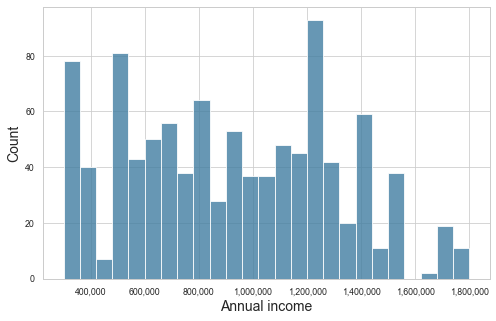

```python
plt.figure(figsize=(8,5))
g = sns.histplot(data=plot_data, x=quant_cols[1], bins=25, alpha=0.8)
xlabels = ['{:,.0f}'.format(x) for x in g.get_xticks()]
g.set_xticklabels(xlabels)
ax.set(ylabel="Count")
plt.show()
```

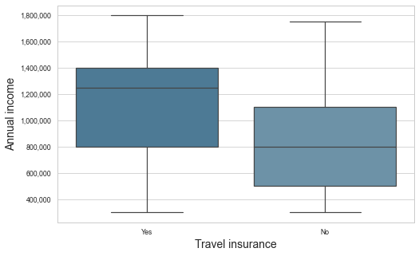

```python
plt.figure(figsize=(8,5))
g = sns.boxplot(data=plot_data, y=quant_cols[1], x="Travel insurance")
ylabels = ['{:,.0f}'.format(y) for y in g.get_yticks()]
g.set_yticklabels(ylabels)
plt.show()
```

##### **Age and family members**

The below count plots shows that most of the clients were 28 years old. The most frequent values for number of family memebers were in range between 3 and 5. Although it is hard to find any accurate dependencies between categorical variables and fact of buying an insurance, there are some slight patterns. For instance, people being 25-26 years old and in their middle 30s buy insurance more often than people being between 27 and 32 years old.

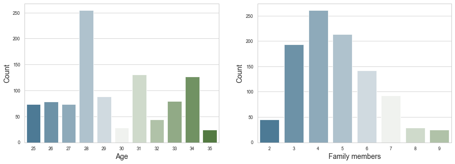

```python
nplots = len(ord_cols)
fig, axs = plt.subplots(1, nplots, figsize=(15, 5))
for i, plot in enumerate(ord_cols):
    sns.countplot(data=plot_data, x=ord_cols[i], ax=axs[i])
    axs[i].set(ylabel="Count")
```

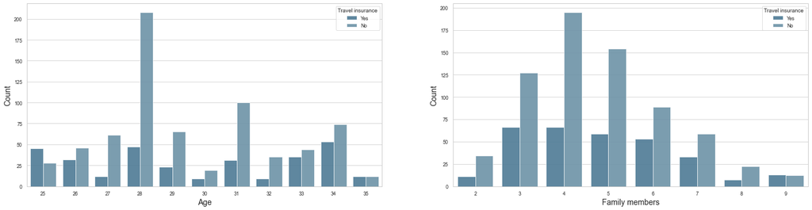

```python
nplots = len(ord_cols)
fig, axs = plt.subplots(1, nplots, figsize=(25, 6))
for i, plot in enumerate(ord_cols):
    sns.countplot(data=plot_data, x=ord_cols[i], alpha=0.9,
                  hue="Travel insurance", ax=axs[i])
    axs[i].set(ylabel="Count")
```

#### **Qualitative variables**

The plots below indicated that people who have ever travelled abroad are more keen to buy an insurance than people who travel abroad for the first time. The proportion of people who took an insurane is much lower among the group of people who had never been in foreign country than amoung indivisuals who travelled abroad. Additionally, insurances are bought more often by poeple employed in private sector than those who work for government. It seems that the fact of having chronic disease or being graduate does not effect decision about purchase of insurance. In contrast, frequent flyers are more likely to buy an insurance. The exact values of the countbars can be checked on the frequency matrices drawn below.

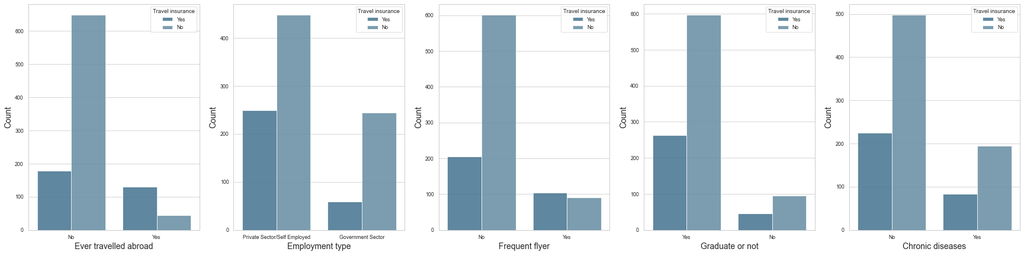

```python
target_col = "Travel insurance"
qual_cols = list(set(plot_data.columns).difference(quant_cols))
qual_cols.remove(target_col)

nplots = len(qual_cols)
fig, axs = plt.subplots(1, nplots, figsize=(30, 7))
for i, plot in enumerate(qual_cols):
    sns.countplot(data=plot_data, x=qual_cols[i], hue="Travel insurance", ax=axs[i], alpha=0.9,
                  order=plot_data[qual_cols[i]].value_counts().index)
    axs[i].set(ylabel="Count")
```

```python
class color:
    """Enables formatting printed strings."""
    RED = '\033[91m'
    BOLD = '\033[1m'
    UNDERLINE = '\033[4m'
    END = '\033[0m'

def get_freq_matrix(series_1, series_2, percentage=False):
    """Returns matrix of values frequencies between two categorical columns."""
    s_1_unique = [str(s) for s in series_1.unique()]
    s_2_unique = [str(s) for s in series_2.unique()]

    temp_df = pd.DataFrame({"col_1": series_1.astype(str), "col_2": series_2.astype(str)})
    freq_matrix = pd.DataFrame(index=s_1_unique, columns=s_2_unique)
    n = len(series_1)

    for s_1 in s_1_unique:
        for s_2 in s_2_unique:
            freq_matrix.loc[s_1, s_2] = len(temp_df[(temp_df["col_1"] == s_1) & (temp_df["col_2"] == s_2)])
            if percentage:
                freq_matrix.loc[s_1, s_2] /= n

    return freq_matrix
```

```python
for var in qual_cols:
    print(color.BOLD + var + color.END)
    print(get_freq_matrix(plot_data[var], plot_data["Travel insurance"], percentage=True))
    print("-" * 50)
```

```
Ever travelled abroad
      Yes    No
Yes 0.130 0.043
No  0.178 0.649
--------------------------------------------------
Employment type
                               Yes    No
Private Sector/Self Employed 0.249 0.448
Government Sector            0.059 0.244
--------------------------------------------------
Frequent flyer
      Yes    No
Yes 0.103 0.091
No  0.205 0.601
--------------------------------------------------
Graduate or not
      Yes    No
Yes 0.263 0.597
No  0.045 0.095
--------------------------------------------------
Chronic diseases
      Yes    No
No  0.225 0.498
Yes 0.083 0.194
--------------------------------------------------
```

## 2. Train-test split

In the next step, dataset was split into train and test sets in proportion 80:20. Argument "stratify" was used to guarantee the same proportion of 1 and 0 labels in target column for both sets. Also for the remaining columns, descriptive statistics of both sets remained similar.

```python
def swap_dict(_dict):
    """Swap keys and values in dictionary."""
    new_dict = {v: k for k, v in _dict.items()}
    return new_dict

data_mapped = raw_data.copy()
# replace "yes" with 1 and "no" with 0 to make columns valid input to ML
data_mapped["empl_type"] = np.where(data_mapped["empl_type"] == "Private Sector/Self Employed", 1, 0)
data_mapped = data_mapped.replace(swap_dict(binary_map))
```

```python
coln = data_mapped.shape[1] - 1
X, y = data_mapped.iloc[:, :coln], data_mapped.iloc[:, coln]
X_train, X_test, y_train, y_test = train_test_split(X, y, test_size=0.2, random_state=seed, stratify=y)
```

```python
X_train.shape, X_test.shape, y_train.shape, y_test.shape
```

```
((800, 8), (200, 8), (800,), (200,))
```

```python
X_train.describe().T
```

|  | count | mean | std | min | 25% | 50% | 75% | max |
| --- | --- | --- | --- | --- | --- | --- | --- | --- |
| age | 800.000 | 29.641 | 2.932 | 25.000 | 28.000 | 29.000 | 32.000 | 35.000 |
| empl_type | 800.000 | 0.693 | 0.462 | 0.000 | 0.000 | 1.000 | 1.000 | 1.000 |
| graduate | 800.000 | 0.863 | 0.345 | 0.000 | 1.000 | 1.000 | 1.000 | 1.000 |
| income | 800.000 | 916125.000 | 374804.058 | 300000.000 | 600000.000 | 900000.000 | 1200000.000 | 1800000.000 |
| family | 800.000 | 4.729 | 1.581 | 2.000 | 4.000 | 5.000 | 6.000 | 9.000 |
| chronic_disease | 800.000 | 0.271 | 0.445 | 0.000 | 0.000 | 0.000 | 1.000 | 1.000 |
| freq_flyer | 800.000 | 0.207 | 0.406 | 0.000 | 0.000 | 0.000 | 0.000 | 1.000 |
| travel_abroad | 800.000 | 0.164 | 0.370 | 0.000 | 0.000 | 0.000 | 0.000 | 1.000 |

```python
X_test.describe().T
```

|  | count | mean | std | min | 25% | 50% | 75% | max |
| --- | --- | --- | --- | --- | --- | --- | --- | --- |
| age | 200.000 | 29.385 | 2.691 | 25.000 | 28.000 | 29.000 | 31.000 | 35.000 |
| empl_type | 200.000 | 0.715 | 0.453 | 0.000 | 0.000 | 1.000 | 1.000 | 1.000 |
| graduate | 200.000 | 0.850 | 0.358 | 0.000 | 1.000 | 1.000 | 1.000 | 1.000 |
| income | 200.000 | 916000.000 | 394680.712 | 300000.000 | 550000.000 | 900000.000 | 1250000.000 | 1750000.000 |
| family | 200.000 | 4.740 | 1.645 | 2.000 | 3.000 | 4.000 | 6.000 | 9.000 |
| chronic_disease | 200.000 | 0.300 | 0.459 | 0.000 | 0.000 | 0.000 | 1.000 | 1.000 |
| freq_flyer | 200.000 | 0.140 | 0.348 | 0.000 | 0.000 | 0.000 | 0.000 | 1.000 |
| travel_abroad | 200.000 | 0.210 | 0.408 | 0.000 | 0.000 | 0.000 | 0.000 | 1.000 |

```python
y_test.mean(), y_train.mean()
```

```
(0.31, 0.3075)
```

## 3. Data standardization

In this part the train and test set were standardized using the mean and standard deviation calculated from training set. Standardization can be beneficial, because improves the numerical stability of the model and often reduces time of model building. For some models, such as kNN, standarization is essential, since variables given in different units would mislead the algorithm which is based on distance metrics.

```python
def scale_train_test(X_train, X_test):
    """
    Calculates mean (m) and standard deviation (sd)
    of a training set and standardizes both train and test set
    According to the formula z = (x - m) / sd.
    """
    m, sd = X_train.mean(), X_train.std()
    X_train_scaled = (X_train - m) / sd
    X_test_scaled = (X_test - m) / sd
    return X_train_scaled, X_test_scaled
```

```python
X_train_scaled, X_test_scaled = scale_train_test(X_train, X_test)
```

## 4. Models training

This section vocers training 4 models: k-Nearest Neighbours, Naive Bayes Classifier, Logistic Regression and Classification Tree and evaluation of their performance.

### k-Nearest Neighbor Classifier

K-Nearest Neighbor Classifier is the first model we train.

In k-Nearest Neighbor Classifier we consider $N$ pairs $(x_1, g_1), ..., (x_N, g_N)$ where $x_i$ is a feature vector of $i$-th observation in a training set and $g_i$ is class label, which takes values in $\{0, 1\}$ for binary classification problem. The given query point $x_0$ is classified to the class which is most freequent among $k$ closest points in its neighborhood. Closest neighbors are usually defined by Euclidean distance after standardization of quantitative features in dataset, to have a mean 0 and variance 1, as they are usually in different units. For the best choices of tuning parameter $k$, the plot showing accuracy scores as a function of neighborhood size was drawn.

```python
skf = StratifiedKFold(n_splits=5, shuffle=True, random_state=seed)
skf_acc, acc_train, auc_train = [], [], []

k_list = list(range(1,30,2))
for k in k_list:
    knn = KNeighborsClassifier(n_neighbors=k)
    knn.fit(X_train_scaled, y_train)
    y_pred_train = knn.predict(X_train_scaled)
    acc_train.append(accuracy_score(y_pred_train, y_train))
    auc_train.append(roc_auc_score(y_pred_train, y_train))
    skf_acc_k = []
    for train_idx, test_idx in skf.split(X_train_scaled, y_train):
        X_train_fold, X_test_fold = X_train_scaled.iloc[train_idx], X_train_scaled.iloc[test_idx]
        y_train_fold, y_test_fold = y_train.iloc[train_idx], y_train.iloc[test_idx]
        knn.fit(X_train_fold, y_train_fold)
        y_pred = knn.predict(X_test_fold)
        skf_acc_k.append(accuracy_score(y_pred, y_test_fold))
    skf_acc.append(mean(skf_acc_k))

k_tune_df = pd.DataFrame({"Number of Neighbors": k_list,"Train Accuracy": acc_train, "Train ROC AUC": auc_train, "Stratified 5-fold CV": skf_acc})
```

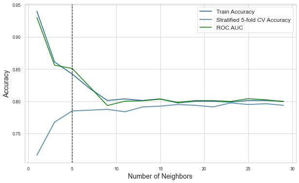

```python
plt.figure(figsize=(10,6))
sns.lineplot(data=k_tune_df, y="Train Accuracy", x="Number of Neighbors",
             label="Train Accuracy", linewidth = 2)
ax = sns.lineplot(data=k_tune_df, y="Stratified 5-fold CV", x="Number of Neighbors",
                  label="Stratified 5-fold CV Accuracy", linewidth = 2)
ax = sns.lineplot(data=k_tune_df, y="Train ROC AUC", x="Number of Neighbors",
                  label="ROC AUC", linewidth = 1.5, color="green")
plt.axvline(5, 0, 1, linestyle='--', color="black")
ax.set(ylabel="Accuracy")
plt.legend(fontsize=12, loc='upper right')
plt.show()
```

```python
# choice of hyperparameter k
k = 5
```

```python
def fevaluate_model(y_test, y_pred):
    """
    Returns dictionary of main metrics used to evaluate a classification model,
    Comaprind predictions with actual values.
    Takes two arguments: real Y values and predicted Y values respectively.
    """
    # acc, roc_auc
    acc = accuracy_score(y_pred, y_test)
    err = 1 - acc
    auc = roc_auc_score(y_pred, y_test)

    # calculate TN, FN, FP, TP
    TN, FN, FP, TP = confusion_matrix(y_test, y_pred).ravel()
    # calculate specificity, sensitivity, positive predictive value, and negative predictive value
    recall  = TP / (TP+FN)
    specificity  = TN / (TN+FP)
    PPV = TP / (TP+FP) # precision
    NPV = TN / (TN+FN)

    # F1 score
    F1 = 2*(recall*PPV)/(recall+PPV)

    perf_metrics = {
        "Accuracy": acc,
        "Error rate": err,
        "AUC": auc,
        "Recall": recall,
        "Specificity": specificity,
        "PPV": PPV,
        "NPV": NPV,
        "F1": F1,
    }

    return perf_metrics


def evaluate_model(clf, X_test, y_test, X_train=None, y_train=None, verbose=True, threshold=0.5):
    """
    Returns dictionary of metrics assessing model performance on test set and,
    Optionally, on train set for a given classification threshold.
    Takes three mandatory arguments: trained model, X test set and y test vector.
    Optional arguments are: X train set, y train vector, boolean parameter indicating,
    If results should be printed (default True), and threshold value (default 0.5).
    """
    def eval_print(metrics_dict, set_name="test"):
        """Prints values of model performance metrcics stored in dictionary."""
        print(color.BOLD + f"Evaluation measures on {set_name} set:" + color.END)
        for key, value in metrics_dict.items():
            print(f"{key}: {round(value, 3)}")
        print("-"*40)

    perf_metrics = {}

    if X_train is not None and y_train is not None:
        # check model performance on train set
        y_pred_train = (clf.predict_proba(X_train)[:,1] >= threshold).astype(bool)
        train_metrics = fevaluate_model(y_pred_train, y_train)

        if verbose:
            eval_print(train_metrics, set_name="train")

        perf_metrics["Train"] = train_metrics

    # check model performance on test set
    y_pred_test = (clf.predict_proba(X_test)[:,1] >= threshold).astype(bool)
    test_metrics = fevaluate_model(y_pred_test, y_test)

    if verbose:
        eval_print(test_metrics)

    perf_metrics["Test"] = test_metrics

    return perf_metrics
```

Train and test performance metrics of kNN are very similar, so only test set results are going to be described.

The built k-NN classifier is able to predict 84.5% of test observations correctly. Area under the ROC is 78.6% what gives way better result than random classifier but its value as well as level of model accuracy are not exceptionally good. Value of recall, which express proportion of observations from positive class which were predicted correctly, is equal to 62.9% only. Specificity indicates that 94.2% of people who wouldn't take the insurence were correctly classified by the model. The precision (PPV) value of 0.83 says that when model predicts that person will buy an insurance, it is correct in 83% of the time. The F1 score which measures both precision and recall equals 71,6%. In general, these results are not very high and would not be helpful for travel agency as model ability of identification people taking the insurance is rather poor. It addresses that one should take steps to improve the model performance or try to build different model.

```python
knn = KNeighborsClassifier(n_neighbors=k)
knn.fit(X_train_scaled, y_train)
knn_perf_metrics = evaluate_model(knn, X_test_scaled, y_test, X_train_scaled, y_train)
```

```
Evaluation measures on train set:
Accuracy: 0.842
Error rate: 0.157
AUC: 0.769
Recall: 0.577
Specificity: 0.96
PPV: 0.866
NPV: 0.836
F1: 0.693
----------------------------------------
Evaluation measures on test set:
Accuracy: 0.845
Error rate: 0.155
AUC: 0.786
Recall: 0.629
Specificity: 0.942
PPV: 0.83
NPV: 0.85
F1: 0.716
----------------------------------------
```

```python
def plot_conf_matrix_clf(clf, X_test, y_test):
    """
    Plots confusion matrix based on trained model,
    X test set, and y test, provided as arguments.
    """
    color = 'black'
    matrix = plot_confusion_matrix(clf, X_test, y_test, cmap=plt.cm.Blues)
    matrix.ax_.set_title('Confusion Matrix', color=color)
    plt.xlabel('Predicted Label', color=color)
    plt.ylabel('True Label', color=color)
    plt.gcf().axes[0].tick_params(colors=color)
    plt.gcf().axes[1].tick_params(colors=color)
    plt.grid(False)
    plt.show()

def plot_conf_matrix(y_test, y_pred):
    """
    Plots confusion matrix based on predicted
    And real values of target variable y.
    """
    color = 'black'
    cf_matrix = confusion_matrix(y_test, y_pred)
    ax = sns.heatmap(cf_matrix, annot=True, cmap=plt.cm.Blues, fmt='g')
    ax.set_xlabel('Predicted labels', color=color)
    ax.set_ylabel('True labels', color=color)
    ax.set_title('Confusion Matrix', color=color)
    plt.grid(False)
    plt.show()
```

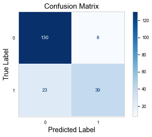

```python
plot_conf_matrix_clf(knn, X_test_scaled, y_test)
```

The plot below shows the model predictions of test set with respect to the Age and Annual Income variables. Green points indicate observations which were classified to the correct group. As per plot, most of the model missclassifications come from positive class. On the plot it is hard to notice any distinctive pattern which drives model decissions when it comes to presented features. On the other hand, it seems that most of model errors could have been avoided if it had taken into consideration values of Annual Income, since people with annual income below the feature mean are much less probable to buy an insurance.

```python
def plot_decision_boundary(data, x_axis_col, y_axis_col, y_pred_col, y_true_col):
    plt.figure(figsize=(10,7))
    sns.scatterplot(data=data[(plot_data_knn[y_pred_col] == "Yes") & (data[y_true_col] == "Yes")],
                    x=x_axis_col, y=y_axis_col, s=170, label="Yes", marker="+", color="green")
    sns.scatterplot(data=data[(plot_data_knn[y_pred_col] == "No") & (data[y_true_col] == "No")],
                    x=x_axis_col, y=y_axis_col,  s=40, label="No", marker="o", color="green")
    sns.scatterplot(data=data[(plot_data_knn[y_pred_col] == "Yes") & (data[y_true_col] == "No")],
                    x=x_axis_col, y=y_axis_col, s=170, marker="+", color="red")
    ax = sns.scatterplot(data=data[(plot_data_knn[y_pred_col] == "No") & (data[y_true_col] == "Yes")],
                         x=x_axis_col, y=y_axis_col, s=40, marker="o", color="red")

    ax.set(ylabel=y_axis_col, xlabel=x_axis_col)
    plt.legend(fontsize=12, loc='center right', title='Predcited class', title_fontsize=14)
    plt.show()
```

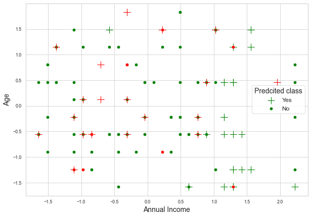

```python
plot_data_knn = X_test_scaled.copy()
plot_data_knn = plot_data_knn.rename(columns={"income": "Annual Income", "age": "Age"})
plot_data_knn["Insurance_pred"] = knn.predict(X_test_scaled)
plot_data_knn["Insurance_pred"] = plot_data_knn["Insurance_pred"].map({0:"No", 1:"Yes"})
plot_data_knn["Insurance_true"] = y_test
plot_data_knn["Insurance_true"] = plot_data_knn["Insurance_true"].map({0:"No", 1:"Yes"})

plot_decision_boundary(plot_data_knn, "Annual Income", "Age", "Insurance_true", "Insurance_pred")
```

## Naive Bayesian Classifier

Naive Bayesian Classifier was second model built in this project.

Having the observation $X = (x_1, ..., x_p)$ and $m$ classes $C_1, ..., C_m$, the Naive Bayes Classifier predicts that $X$ belongs to the class having the highest probability, conditioned on $X$, given as $P(C_i|X)$. By Bayes’ theorem, it can be transformed as follows:

$$ P(C_i|X) = \frac{P(X|C_i) \cdot P(C_i)}{P(X)} $$

Because the equation above can be computationally expensive, Naive Bayes' technique makes a naive assumption that the classes are equally likely, so $P(C_i)=...=P(C_m)$, and that the attributes' values are conditionally independent of one another. Thus,

$$ P(X|C_i) = P(x_1|C_i) \cdot\ ...\ \cdot P(x_p|C_i) $$

As $P(x_1|C_i), ..., P(x_p|C_i)$ can be easily estimated from the training set, the query point $X$ is classified to the class which maximizes this component.

If attribute $A_k$ is categorical, $P(x_k|C_i)$ is calculated as number of training examples having value $x_k$ of $A_k$ and belonging to the $C_i$ class divided by number of points in class $C_i$. If the attribute is continuous, it is assumed to follow the normal distribution. Next, the mean $\mu_{C_i}$ and standard deviation $\sigma_{C_i}$ of $A_k$ from examples belonging to $C_i$ are calculated, and probability $P(x_k|C_i)$ is given as $g(x_k, \mu_{C_i}, \sigma_{C_i})$, where $g$ is probability density function of a normal distribution.

Because some features included in this dataset are categorical while other continuous, Mixed Naive Bayes model was built for this task.

To predict insurance purchase, the Mixed Bayes Classifier was built. Person age, annual income and faimly members were taken as numeric variables. The remaining features were assumed to be categorical. The model accuracy is 0.82. It means that model is able to predict 82% of people decisions about buying insurance. The precision value of 0.771 says that when model predicts that person would buy an insurance, it is correct in 77.1% of the time. Additionally, recall equal to 0.597 means that model correctly identifies only 59,7% of all indivisuals who bought an insurance. Specificity indicates that 92% of people who did not buy an insurance were correctly identified by the model. The F1 score equals 67.3%. Those results suggests that Naive Bayes Classifier performance is quite poor, especially predicting observations from positive class.

```python
mixed_nb = MixedNB(categorical_features=[1,2,5,6,7])
mixed_nb.fit(X_train, y_train)
mixed_nb_perf_metrics = evaluate_model(mixed_nb, X_test, y_test, X_train, y_train)
```

```
Evaluation measures on train set:
Accuracy: 0.776
Error rate: 0.224
AUC: 0.694
Recall: 0.48
Specificity: 0.908
PPV: 0.698
NPV: 0.797
F1: 0.569
----------------------------------------
Evaluation measures on test set:
Accuracy: 0.82
Error rate: 0.18
AUC: 0.759
Recall: 0.597
Specificity: 0.92
PPV: 0.771
NPV: 0.836
F1: 0.673
----------------------------------------
```

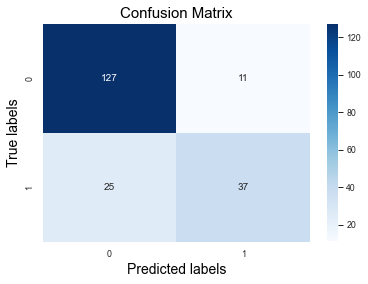

```python
y_pred_mixed_nb = mixed_nb.predict(X_test)
plot_conf_matrix(y_test, y_pred_mixed_nb)
```

The plot below shows the decision boundary of Bayes Classifier in respect to person annual income and fact if they have ever travelled abroad. Model did most of mistakes predicting postitive class.

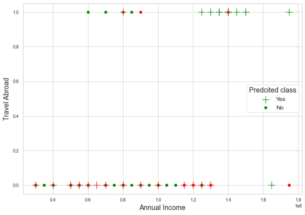

```python
plot_data_nb = X_test.copy()
plot_data_nb = plot_data_nb.rename(columns={"income": "Annual Income", "travel_abroad": "Travel Abroad"})
plot_data_nb["Insurance_pred"] = y_pred_mixed_nb
plot_data_nb["Insurance_pred"] = plot_data_nb["Insurance_pred"].map({0:"No", 1:"Yes"})
plot_data_nb["Insurance_true"] = y_test
plot_data_nb["Insurance_true"] = plot_data_nb["Insurance_true"].map({0:"No", 1:"Yes"})

plot_decision_boundary(plot_data_nb, "Annual Income", "Travel Abroad", "Insurance_true", "Insurance_pred")
```

## Logistic Regression

Logistic regression model represents logarithm of odds (ratio of condidtional probabilities that $X$ belongs to the first and second class) via linear function in $X = (x_1, ..., x_p)$, while at the same time probabilities remain in $[0, 1]$. It has the following form:

$$ \log{\frac{P(C_1|X)}{1 - P(C_1|X)}} = \beta_{0} + \beta_1X $$

After some calculations, it can be transformed to the form of sigmoid function:

$$ P(C_1|X) = \frac{1}{1 + e^{-(\beta_{0} + \beta_1X)}} $$

Having given the training set, model parameters are estimated with use of Maximum Likelihood Method.

Logistic regression model was trained on the standardized train set data and its accuracy, equal to 84.0%, is similar to k-NN model. The precision score is equal to 84.1%, recall equals 59.7% and specificity equals 94.9%. It means that 84.1% of people thought by the classifier to buy insurance, actually did it. Value of recall says that out off all people who bought insurance, only 59.7% were correctly forecasted. Specificity indicates that 94.9% of people travelling without insurance were classified to the correct class. The F1 score which measures the overall performance, including both the precision and recall, equals 69.8%.

```python
lr = LogisticRegression()
lr.fit(X_train_scaled, y_train)
lr_perf_metrics = evaluate_model(lr, X_test_scaled, y_test, X_train_scaled, y_train)
```

```
Evaluation measures on train set:
Accuracy: 0.798
Error rate: 0.202
AUC: 0.709
Recall: 0.48
Specificity: 0.939
PPV: 0.776
NPV: 0.802
F1: 0.593
----------------------------------------
Evaluation measures on test set:
Accuracy: 0.84
Error rate: 0.16
AUC: 0.773
Recall: 0.597
Specificity: 0.949
PPV: 0.841
NPV: 0.84
F1: 0.698
----------------------------------------
```

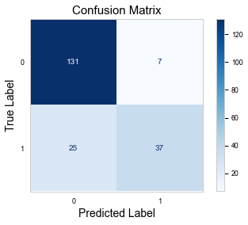

```python
plot_conf_matrix_clf(lr, X_test_scaled, y_test)
```

## Classification Tree

As per classification tree model, it predicts that query observation $X$ belongs to the most commonly occurring class among training observations in the region to which it belongs. To build the regions, the recursive binary splitting technique is used. The approach recursively splits the preditor space, what is indicated by adding new branches from top to dow of the tree, aiming to make a high quality split. The evaluation of split qulity is done based on Gini index (G):

$$ G = \sum^{K}_{k=1}{\hat{p}_{mk}(1 - \hat{p}_{mk})} $$

or alternatively, based on Entropy (D), given as:

$$ D = - \sum^{K}_{k=1}{\hat{p}_{mk}\log{\hat{p}_{mk}}} $$

The $\hat{p}_{mk}$ represents proportion of observation from $k$-th class being in $m$-th region. Both metrics take on a small value if the $m$-th node is pure, what means that after the split, one class predominate over the rest.

The built classification tree model seems to be overfitted - assessment metrics calculated on the train set are much better than these estimated for train set. To handle this issue, it was decided to apply hyperparameter tunning to reduce model variance and find tree which has enough ability to generalize the patterns and make good predictions on test set.

```python
clf_tree = DecisionTreeClassifier(random_state=seed)
clf_tree.fit(X_train, y_train)
dt_perf_metrics = evaluate_model(clf_tree, X_test, y_test, X_train, y_train)
```

```
Evaluation measures on train set:
Accuracy: 0.949
Error rate: 0.051
AUC: 0.945
Recall: 0.935
Specificity: 0.955
PPV: 0.902
NPV: 0.971
F1: 0.918
----------------------------------------
Evaluation measures on test set:
Accuracy: 0.795
Error rate: 0.205
AUC: 0.776
Recall: 0.726
Specificity: 0.826
PPV: 0.652
NPV: 0.87
F1: 0.687
----------------------------------------
```

### Hyperparameter tunning

```python
max_depth = list(range(2,10,1))
min_samples_split = list(range(5,16,5))

skf = StratifiedKFold(n_splits=5, shuffle=True, random_state=seed)
skf_acc, skf_auc, depth_list, min_ss_list = [], [], [], []

for s in min_samples_split:
    for d in max_depth:
        clf_tree = DecisionTreeClassifier(max_depth=d, min_samples_split=s, random_state=seed)
        clf_tree.fit(X_train, y_train)
        y_pred_train = clf_tree.predict(X_train)
        skf_acc_s, skf_auc_s = [], []
        for train_idx, test_idx in skf.split(X_train, y_train):
            X_train_fold, X_test_fold = X_train.iloc[train_idx], X_train.iloc[test_idx]
            y_train_fold, y_test_fold = y_train.iloc[train_idx], y_train.iloc[test_idx]
            clf_tree.fit(X_train_fold, y_train_fold)
            y_pred = clf_tree.predict(X_test_fold)
            skf_acc_s.append(accuracy_score(y_pred, y_test_fold))
            skf_auc_s.append(roc_auc_score(y_pred, y_test_fold))
        skf_acc.append(mean(skf_acc_s))
        skf_auc.append(mean(skf_auc_s))
        min_ss_list.append(s)
        depth_list.append(d)

tree_tune_df = pd.DataFrame({"Tree size": depth_list,
                             "Min. samples split": min_ss_list,
                             "Cross-Validation ROC AUC": skf_auc,
                             "Cross-Validation Accuracy": skf_acc})
```

The plots below show the cross-validation accuracy and cross-validation ROC AUC value for different tree levels and minimum samples to split. One can easily notice that based on accuracy, the best number of tree levels is 3. For most cases, accuracy score dicreases as tree size increases. According to the second plot, ROC AUC has the best value for tree size equal to 2. For small tree sizes, total minimum samples to split the node seem to not differ between tested values. For larger trees, minimum value equal to 10 seems to sligtly outperform other parameter values. It is probably because higher value of this parameter reduces effect of overfitting caused by building too large tree.

To build the final model, it was decided to take maximum depth equal to 3 and minimum number of samples in the node to make a split equal to 10.

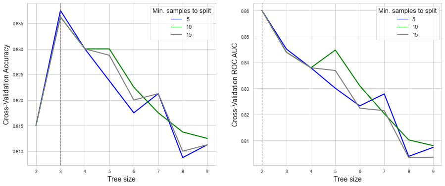

```python
fig, axs = plt.subplots(1, 2, figsize=(15, 6))
sns.lineplot(data=tree_tune_df, y="Cross-Validation Accuracy", x="Tree size", hue="Min. samples split",
             ax=axs[0], linewidth = 2, palette=["blue", "green", "grey"])
axs[0].axvline(3, 0, 1, linestyle='--', color="grey")
axs[0].legend(fontsize=11, loc='upper right', title='Min. samples to split', title_fontsize=13)

sns.lineplot(data=tree_tune_df, y="Cross-Validation ROC AUC", x="Tree size", hue="Min. samples split",
             ax=axs[1], linewidth = 2, palette=["blue", "green", "grey"])
axs[1].axvline(2, 0, 1, linestyle='--', color="grey")
axs[1].legend(fontsize=11, loc='upper right', title='Min. samples to split', title_fontsize=13)
plt.show()
```

```python
# maximum depth and minimum samples to split parameters
depth = 3
samples_split = 10
```

```python
clf_tree = DecisionTreeClassifier(max_depth=depth, min_samples_split=samples_split, random_state=seed)
clf_tree.fit(X_train, y_train)
clf_tree_perf_metrics = evaluate_model(clf_tree, X_test, y_test, X_train, y_train)
```

```
Evaluation measures on train set:
Accuracy: 0.84
Error rate: 0.16
AUC: 0.761
Recall: 0.557
Specificity: 0.966
PPV: 0.878
NPV: 0.831
F1: 0.682
----------------------------------------
Evaluation measures on test set:
Accuracy: 0.875
Error rate: 0.125
AUC: 0.812
Recall: 0.645
Specificity: 0.978
PPV: 0.93
NPV: 0.86
F1: 0.762
----------------------------------------
```

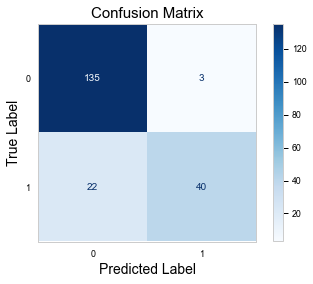

```python
plot_conf_matrix_clf(clf_tree, X_test, y_test)
```

The plot below shows the decision tree which gives nice visual representation of each model decision. Apparently, the annual income was the most predicitive feature as it was selected to create most of the rules. The color of the leaf is coresponding to the predicted value. One can notice that some of the rules are redundant as both leafs of a particular node gives the same decision about classification. In such case, the tree could be pruned.

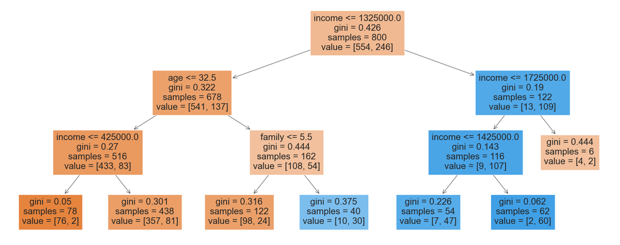

```python
fig = plt.figure(figsize=(25,10))
_ = plot_tree(clf_tree, feature_names=X_test.columns, filled=True)
```

```python
# data frame storing classification results of all the models
master_results = pd.DataFrame(columns=["Model", "Class imbalance approache", "Accuracy", "Recall", "Specificity", "Precision", "AUC"])

def update_master_results(model_names, model_version, models_pm, master_results):
    """Updates master_results data frame with performance metrics of new models."""

    for i, model_name in enumerate(model_names):
        test_pm = models_pm[i].get("Test")
        acc = test_pm.get("Accuracy")
        recall = test_pm.get("Recall")
        specificity = test_pm.get("Specificity")
        ppv = test_pm.get("PPV")
        auc = test_pm.get("AUC")
        new_row = [model_name, model_version, acc, recall, specificity, ppv, auc]
        master_results.loc[len(master_results)] = new_row

    return master_results
```

```python
model_names = ["k-Nearest Neighbor Classifier", "Naive Bayes Classifier", "Logistic Regression", "Classification Tree"]
model_version = "Basic"
models_pm = [knn_perf_metrics, mixed_nb_perf_metrics, lr_perf_metrics, clf_tree_perf_metrics]

master_results = update_master_results(model_names, model_version, models_pm, master_results)
```

The table below gathers results of all 4 models. Out of all models the best results obtains classification tree. The poorest performance characterizes Naive Bayes Classifier.

```python
master_results[-4:]
```

|  | Model | Class imbalance approache | Accuracy | Recall | Specificity | Precision | AUC |
| --- | --- | --- | --- | --- | --- | --- | --- |
| 0 | k-Nearest Neighbor Classifier | Basic | 0.845 | 0.629 | 0.942 | 0.830 | 0.786 |
| 1 | Naive Bayes Classifier | Basic | 0.820 | 0.597 | 0.920 | 0.771 | 0.759 |
| 2 | Logistic Regression | Basic | 0.840 | 0.597 | 0.949 | 0.841 | 0.773 |
| 3 | Classification Tree | Basic | 0.875 | 0.645 | 0.978 | 0.930 | 0.812 |

```python
knn_proba = knn.predict_proba(X_test_scaled)[::,1]
mixed_nb_proba = mixed_nb.predict_proba(X_test)[::,1]
lr_proba = lr.predict_proba(X_test_scaled)[::,1]
clf_tree_proba = clf_tree.predict_proba(X_test)[::,1]

model_proba = [knn_proba, mixed_nb_proba, lr_proba, clf_tree_proba]

result_df = pd.DataFrame(columns=["Model", "TPR", "FPR", "AUC"])

for i, model_prob in enumerate(model_proba):
    FPR, TPR, thresholds = roc_curve(y_test, model_prob)
    AUC = roc_auc_score(y_test, model_prob)

    result_df = result_df.append({'Model': model_names[i],
                                 'FPR': FPR,
                                 'TPR': TPR,
                                 'AUC': AUC,
                                 'Thresholds': thresholds}, ignore_index=True)

result_df.set_index('Model', inplace=True)
```

ROC plot tells how much the model is capable of distinguishing between classes. Clearly the k-NN model performs better when classifying observations into categories compared to the other models.

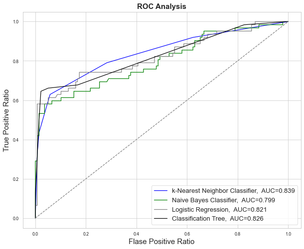

```python
plt.figure(figsize=(10, 8))
colors = ["blue", "green", "grey", "black"]
for i, model in enumerate(result_df.index):
        plt.plot(result_df.loc[model]['FPR'],
                 result_df.loc[model]['TPR'],
                 label=f"{model},  AUC={round(result_df.loc[model]['AUC'], 3)}",
                 color=colors[i])
plt.plot([0,1], [0,1], color='grey', linestyle='--')
plt.xlabel("Flase Positive Ratio", fontsize=15)
plt.ylabel("True Positive Ratio", fontsize=15)
plt.title('ROC Analysis', fontweight='bold', fontsize=15)
plt.legend(prop={'size':13}, loc='lower right')
plt.show()
```

## 5. Improving Classification of Class-Imbalanced Data

All the models trained and presented in the above section have tendency to obtain good results in predicting observations from negative class and poor results when predicting point belonging to the positive class. It is not good, as travel agency is probably more intrested in recognition of people who may potentially buy the insurance. The reason of that is class imbalance problem which is present in this dataset. In short, it means that predicted class labels occure in different proportion. Because traditional algorithms aims to minimize the overall number of errors and treat false positive and false negative errors equally, they might not be suitable to predict class-imbalanced data. To imrpve the model performance in such case, one can apply several methods, including:

- moving the classification threshold
- oversampling and undersampling
- ensemble methods

To address this problem in the following project, two techniques were applied and tested: threshold moving and SMOTE algorithm being example of oversampling method.

### Threshold moving

Multiple threshold values were tested before selecting the final one. It was decided to change the threshold to 35% as for this value, model evaluation metrics seemd to be the best.

```python
tr = 0.35
```

```python
knn_perf_metrics_35 = evaluate_model(knn, X_test_scaled, y_test, threshold=tr, verbose=False)
mixed_nb_perf_metrics_35 = evaluate_model(mixed_nb, X_test, y_test, threshold=tr, verbose=False)
lr_perf_metrics_35 = evaluate_model(lr, X_test_scaled, y_test, threshold=tr, verbose=False)
dt_perf_metrics_35 = evaluate_model(clf_tree, X_test, y_test, threshold=tr, verbose=False)

models_pm = [knn_perf_metrics_35, mixed_nb_perf_metrics_35, lr_perf_metrics_35, dt_perf_metrics_35]
model_version = "Threshold 35%"
master_results = update_master_results(model_names, model_version, models_pm, master_results)
```

After setting threshold value to 35%, models ability to recognize positive cases increased. The biggest difference was noticed for k-NN model, for which recall increased by about 17%. On the other hand, recall hasn't changed at all for classification tree, which results are relatively good anyway. All models except the tree lost accuracy and specificity scores in favour of recall score. Despite that, the increase of recall was not very high comparing to accuracy and specificity drop. Taking it into consideration, it is hard to say that models are better after changing the threshold, even if they are able to recognize people who bought an insurance with higher accuracy.

```python
master_results[-4:]
```

|  | Model | Class imbalance approache | Accuracy | Recall | Specificity | Precision | AUC |
| --- | --- | --- | --- | --- | --- | --- | --- |
| 4 | k-Nearest Neighbor Classifier | Threshold 35% | 0.740 | 0.790 | 0.717 | 0.557 | 0.754 |
| 5 | Naive Bayes Classifier | Threshold 35% | 0.775 | 0.613 | 0.848 | 0.644 | 0.730 |
| 6 | Logistic Regression | Threshold 35% | 0.800 | 0.645 | 0.870 | 0.690 | 0.757 |
| 7 | Classification Tree | Threshold 35% | 0.875 | 0.645 | 0.978 | 0.930 | 0.812 |

### SMOTE Oversampling for Imbalanced Dataset

SMOTE algorithm is oversampling technique which, instead of simple dupicating observations from minority class, generates new points which are combination of current observations and their nearest neigbours. One iteration is done by choosing random point from the minority class. Then, its k nearest neigbours are found based on selected distance metrics and random neigbour is selected. Features of newly added point are made of values calculated as middle value between values of variables of current point and its random nearest neigbour.

```python
smote = SMOTE(random_state=seed)
X_train_smote, y_train_smote = smote.fit_resample(X_train, y_train)
X_train_scaled_smote, _ = scale_train_test(X_train_smote, X_train_smote)
```

```python
y_train_smote.value_counts()
```

```
1    554
0    554
Name: insurance, dtype: int64
```

```python
X_train_smote.shape, X_train_scaled_smote.shape
```

```
((1108, 8), (1108, 8))
```

```python
knn_smote = KNeighborsClassifier(n_neighbors=7)
knn_smote.fit(X_train_scaled_smote, y_train_smote)
knn_perf_metrics_smote = evaluate_model(knn_smote, X_test_scaled, y_test, verbose=False)

mixed_nb_smote = MixedNB(categorical_features=[1,2,5,6,7])
mixed_nb_smote.fit(X_train_smote, y_train_smote)
mixed_nb_perf_metrics_smote = evaluate_model(mixed_nb_smote, X_test, y_test, verbose=False)

lr_smote = LogisticRegression()
lr_smote.fit(X_train_scaled_smote, y_train_smote)
lr_perf_metrics_smote = evaluate_model(lr_smote, X_test_scaled, y_test, verbose=False)

clf_tree_smote = DecisionTreeClassifier(random_state=seed)
clf_tree_smote.fit(X_train_smote, y_train_smote)
dt_perf_metrics_smote = evaluate_model(clf_tree_smote, X_test, y_test, verbose=False)
```

```python
models_pm = [knn_perf_metrics_smote, mixed_nb_perf_metrics_smote, lr_perf_metrics_smote, dt_perf_metrics_smote]
model_version = "SMOTE"
master_results = update_master_results(model_names, model_version, models_pm, master_results)
```

Applying SMOTE oversampling algorithm improves models ability to detect positive samples more than moving the threshold. On the other hand, models accuracy is also the lowest out of all variants. Model which seems to give the best results comparing with others is k-NN.

```python
master_results[-4:]
```

|  | Model | Class imbalance approache | Accuracy | Recall | Specificity | Precision | AUC |
| --- | --- | --- | --- | --- | --- | --- | --- |
| 8 | k-Nearest Neighbor Classifier | SMOTE | 0.760 | 0.742 | 0.768 | 0.590 | 0.755 |
| 9 | Naive Bayes Classifier | SMOTE | 0.770 | 0.694 | 0.804 | 0.614 | 0.749 |
| 10 | Logistic Regression | SMOTE | 0.695 | 0.758 | 0.667 | 0.505 | 0.712 |
| 11 | Classification Tree | SMOTE | 0.740 | 0.677 | 0.768 | 0.568 | 0.723 |

## 6. Conclusion

Looking at the metrics and spider plots below one can notice that applying methods which are meant to handle class imbalance problem, the model recall usually increases. However, it is usually done at the cost of drop in accuracy and other metrices such as specificity and precision.

After analysing the results below, it seems that the best model is Classification Tree without applying any approaches improving classification for class imbalanced data. Alternativel, travel agency could choose k-Nearest Neighbor Classifier with threshold set to 35% if it is more interested in better ability to detect positive samples than overall accuracy.

Obviously, the accuracy and other metrices of both models are too low to trust classification decisions without any doubt of Tree as well as k-NN model. But at the same time, the models can be still important tools which may help travel agency in making better business decisions. Undoubtedly, decision driven by suggestions from the models, and analysed carrefully by analysts and managers, are less risky than those driven only by intuition and basic data analysis.

```python
master_results
```

|  | Model | Class imbalance approache | Accuracy | Recall | Specificity | Precision | AUC |
| --- | --- | --- | --- | --- | --- | --- | --- |
| 0 | k-Nearest Neighbor Classifier | Basic | 0.845 | 0.629 | 0.942 | 0.830 | 0.786 |
| 1 | Naive Bayes Classifier | Basic | 0.820 | 0.597 | 0.920 | 0.771 | 0.759 |
| 2 | Logistic Regression | Basic | 0.840 | 0.597 | 0.949 | 0.841 | 0.773 |
| 3 | Classification Tree | Basic | 0.875 | 0.645 | 0.978 | 0.930 | 0.812 |
| 4 | k-Nearest Neighbor Classifier | Threshold 35% | 0.740 | 0.790 | 0.717 | 0.557 | 0.754 |
| 5 | Naive Bayes Classifier | Threshold 35% | 0.775 | 0.613 | 0.848 | 0.644 | 0.730 |
| 6 | Logistic Regression | Threshold 35% | 0.800 | 0.645 | 0.870 | 0.690 | 0.757 |
| 7 | Classification Tree | Threshold 35% | 0.875 | 0.645 | 0.978 | 0.930 | 0.812 |
| 8 | k-Nearest Neighbor Classifier | SMOTE | 0.760 | 0.742 | 0.768 | 0.590 | 0.755 |
| 9 | Naive Bayes Classifier | SMOTE | 0.770 | 0.694 | 0.804 | 0.614 | 0.749 |
| 10 | Logistic Regression | SMOTE | 0.695 | 0.758 | 0.667 | 0.505 | 0.712 |
| 11 | Classification Tree | SMOTE | 0.740 | 0.677 | 0.768 | 0.568 | 0.723 |

#### Comparing models performance with spider plots

```python
def spider_plot(metrics_lists, labels, plot_title):
    categories = ['Accuracy', 'Recall', 'Specificity', 'Precision', 'AUC']
    N = len(categories)
    angles = [n / float(N) * 2 * np.pi for n in range(N)]
    angles += angles[:1]

    plt.figure(figsize=(10, 10))
    ax = plt.subplot(111, polar=True)
    ax.set_theta_offset(np.pi / 2)
    ax.set_theta_direction(-1)
    plt.xticks(angles[:-1], categories, size=15)
    ax.set_rlabel_position(0.3)
    plt.yticks([0.5, 0.6, 0.7, 0.8, 0.9], color="grey", size=12)
    plt.ylim(0, 1)

    for i in range(len(metrics_lists)):
        values = metrics_lists[i]
        values += values[:1]
        ax.plot(angles, values, linewidth=1.1, linestyle='solid', label=labels[i], color=colors[i])

    plt.title(plot_title, size=20, y=1.05)
    plt.legend(prop={'size': 15})
    plt.show()
```

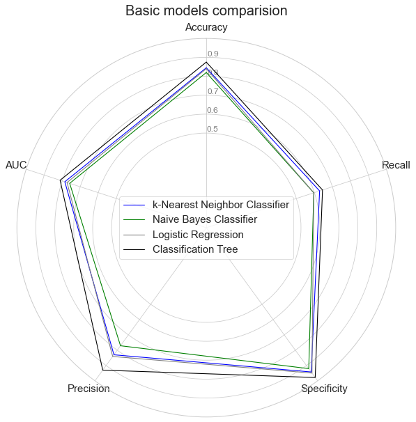

```python
metrics_lists = [list(r)[2:] for r in master_results.values.tolist()][:4]
labels = model_names
plot_title = "Basic models comparision"
spider_plot(metrics_lists, labels, plot_title)
```

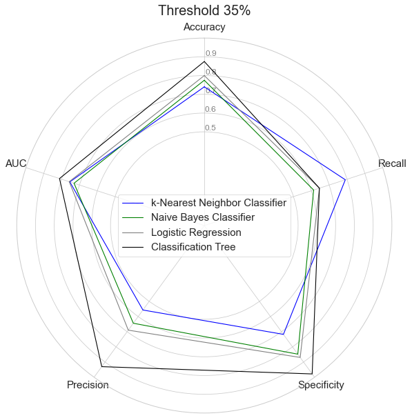

```python
metrics_lists = [list(r)[2:] for r in master_results.values.tolist()][4:8]
plot_title = "Threshold 35%"
spider_plot(metrics_lists, labels, plot_title)
```

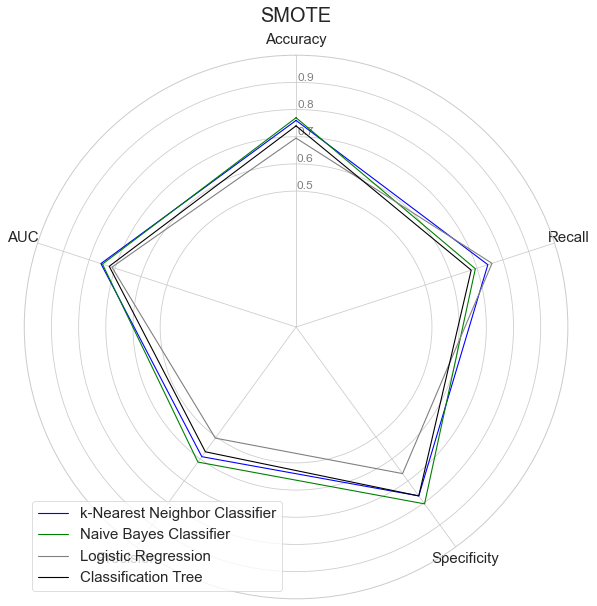

```python
metrics_lists = [list(r)[2:] for r in master_results.values.tolist()][8:]
plot_title = "SMOTE"
spider_plot(metrics_lists, labels, plot_title)
```